# Analýza rizikových faktorů a závažnosti dopravních nehod na federálních dálnicích v Brazílii

Semestrální projekt MLP

Autor

Matěj Severýn

Publikováno

30. prosince 2025

# Executive Summary

Předložená zpráva se zabývá analýzou **2,01 milionu dopravních nehod** zaznamenaných na brazilských federálních dálnicích v časovém rozmezí let 2007–2023. Primárním cílem práce je identifikace determinant ovlivňujících závažnost nehod (klasifikovaných jako nehody s úmrtím nebo těžkým zraněním) a statistická verifikace hypotéz týkajících se vlivu bezpečnostních prvků a environmentálních podmínek.

# 1 Vymezení problematiky (Business Understanding)

## 1.1 Kontext a motivace

Brazílie patří mezi země s nejvyšší mírou dopravní nehodovosti na světě. Federální dálnice (*rodovias federais*) představují kritickou infrastrukturu spojující všechny regiony země, ale zároveň místa vysokého rizika dopravních nehod s vážnými následky. Systematická analýza historických dat umožňuje:

- Identifikovat strukturální a temporální rizikové faktory.
- Kvantifikovat vliv preventivních opatření (např. radary).
- Optimalizovat alokaci zdrojů pro dopravní dohled (PRF).

## 1.2 Cíle projektu

**Primární cíl:** Sestavení a validace klasifikačního modelu pro predikci závažnosti nehody (`target_severe`: 0 = lehká/bez zranění, 1 = těžká/smrtelná).

**Výzkumné hypotézy:**

- **H1:** *Přítomnost stacionárního měřiče rychlosti (v okruhu ≤ 5 km) koreluje s nižší závažností nehod.*
- **H2:** *Nepříznivé meteorologické podmínky zvyšují incidenci nehod, avšak snižují jejich závažnost (mortalitu).*
- **H3:** *Specifický časový segment (víkendové noční hodiny) vykazuje signifikantně vyšší podíl nehod s vážnými následky.*

## 1.3 Metodika

Projekt postupuje dle standardizovaného rámce **CRISP-DM** (Cross-Industry Standard Process for Data Mining):

1. **Data Understanding:** Akvizice, validace a explorace datových sad.
2. **Data Preparation:** Čištění dat, feature engineering a prostorová integrace dat.
3. **Modeling:** Trénink a optimalizace klasifikačních algoritmů (Logistická regrese, Random Forest).
4. **Evaluation:** Vyhodnocení metrik výkonnosti a interpretace výsledků v kontextu stanovených hypotéz.

# 2 Analýza a příprava dat (Data Understanding)

## 2.1 Popis datových zdrojů

V projektu jsou využity dva primární datové zdroje poskytnuté Brazilskou federální dopravní policií (PRF):

1. **Dataset nehod (2007–2023):**
   - Obsahuje 2,01 milionu záznamů o nehodách.
   - **Klíčové atributy:** Časové údaje, geografická poloha (stát, dálnice, km), typ vozovky, meteorologické podmínky, klasifikace následků (počty mrtvých a zraněných), příčina nehody.
2. **Dataset radarů:**
   - Evidence 608 aktivních stacionárních radarů.
   - **Klíčové atributy:** Přesná lokace (km), rychlostní limit a rok instalace (nezbytné pro časovou validaci vůči nehodám).

## 2.2 Akvizice a inicializace dat

**Zobrazit zdrojový kód**

```python
import os
import pandas as pd
import numpy as np
import matplotlib.pyplot as plt
import seaborn as sns
import warnings
from sklearn.model_selection import train_test_split
from sklearn.ensemble import RandomForestClassifier
from sklearn.model_selection import RandomizedSearchCV
from sklearn.model_selection import PredefinedSplit
from sklearn.linear_model import LogisticRegression
from sklearn.metrics import (classification_report, roc_auc_score,
                            confusion_matrix, roc_curve)
from scipy.stats import chi2_contingency

# Konfigurace vizualizací
sns.set_style("whitegrid")
sns.set_palette("deep")
# Globální nastavení menších grafů
plt.rcParams['figure.figsize'] = (10, 5)
plt.rcParams['font.size'] = 10
warnings.filterwarnings('ignore')

def load_all_years(start=2007, end=2023, folder='brazil_nehody'):
    """
    Načte data dopravních nehod ze všech dostupných ročních souborů.
    """
    dfs = []
    if not os.path.exists(folder):
        print(f"CHYBA: Složka '{folder}' neexistuje. Jste ve správném adresáři?")
        return None

    for year in range(start, end+1):
        filename = f'Dados_PRF_{year}.csv'
        file_path = os.path.join(folder, filename)

        try:
            df = pd.read_csv(file_path, sep=';', encoding='latin1',
                           dtype={'br': str, 'km': str}, low_memory=False)
            df['year'] = year
            dfs.append(df)
        except FileNotFoundError:
            print(f"{year}: Soubor nenalezen ({file_path})")
        except Exception as e:
            print(f"{year}: Chyba při načítání: {e}")

    return pd.concat(dfs, ignore_index=True) if dfs else None

# Načtení dat nehod
df_acc = load_all_years()

# Načtení dat radarů
radar_path = os.path.join('brazil_nehody', 'Dados_Radares.csv')
try:
    df_rad = pd.read_csv(radar_path, sep=';', encoding='latin1',
                         dtype={'rodovia': str, 'km_m': str})
except FileNotFoundError:
    print(f"CHYBA: Soubor radarů nenalezen na cestě: {radar_path}")
    df_rad = None

if df_acc is not None and not df_acc.empty:
    years_loaded = sorted(df_acc['year'].unique())
    print(f"Úspěšně načteno {len(df_acc):,} záznamů nehod.")
    print(f"Časové pokrytí: {min(years_loaded)} - {max(years_loaded)}")
    print(f"Úspěšně načteno {len(df_rad):,} záznamů radarů.")
else:
    print("Chyba: Data nejsou k dispozici.")
```

```
Úspěšně načteno 2,013,757 záznamů nehod.
Časové pokrytí: 2007 - 2023
Úspěšně načteno 608 záznamů radarů.
```

**TipExploratorní analýza (ydata-profiling)**

Před zahájením manuálního čištění a transformací byla provedena automatizovaná profilace dat pomocí knihovny **ydata-profiling**. Tento proces poskytl prvotní detailní přehled o distribuci proměnných, korelací a interakcí v surových datech.

Kompletní interaktivní report naleznete zde: report_brazil_nehody.html

## 2.3 Čištění a transformace dat

Vzhledem k délce sledovaného období (17 let) vykazovala data značnou heterogenitu. Pro zajištění konzistence byl aplikován robustní postup čištění:

1. **Standardizace názvů sloupců:** Sjednocení proměnlivých názvů v průběhu let na jednotný anglický standard.
2. **Harmonizace kategorických hodnot:**
   - **Počasí:** Aplikace komplexního slovníku pro sloučení synonym (např. různé zápisy pro “Jasno” nebo “Déšť”) a ošetření chybějících hodnot.
   - **Fáze dne:** Sloučení variant zápisu do čtyř základních fází pomocí “flattening” strategie.
3. **Dynamická validace kilometráže:** Místo plošného ořezání hodnot byla použita **statistická detekce odlehlých hodnot**. Pro každou kombinaci státu (`UF`) a dálnice (`BR`) byl vypočten dynamický limit (99.9% kvantil), čímž byly odstraněny pouze skutečné anomálie specifické pro daný úsek.
4. **Pokročilé parsování času:** Implementace **třífázového parsování data** (`data_inversa`), které automaticky detekuje a sjednocuje formáty ISO (`YYYY-MM-DD`), standardní brazilský (`DD/MM/YYYY`) i zkrácený (`DD/MM/YY`), čímž byla eliminována ztráta dat.

**Zobrazit zdrojový kód**

```python
if not df_acc.empty:
    print("Zahajuji robustní transformaci dat...")

    # 1. STANDARDIZACE NÁZVŮ SLOUPCŮ (Mapování na English pro kompatibilitu reportu)
    cols_map = {
        'data_inversa': 'date',
        'horario': 'time',
        'uf': 'state',
        'br': 'road_num',
        'km': 'km',
        'condicao_metereologica': 'weather',
        'fase_dia': 'day_phase',
        'tipo_pista': 'road_type',
        'tracado_via': 'road_layout',
        'uso_solo': 'land_use',
        'mortos': 'dead',
        'feridos_graves': 'injured_severe',
        'feridos_leves': 'injured_light',
        'ilesos': 'unharmed',
        'ano': 'year',
        'causa_acidente': 'cause',
        'tipo_acidente': 'accident_type',
        'classificacao_acidente': 'classification',
        'sentido_via': 'road_direction',
        'municipio': 'city'
    }

    # Přejmenování pouze existujících sloupců a odstranění duplicit
    df = df_acc.rename(columns=cols_map)
    df = df.loc[:, ~df.columns.duplicated()]

    # 2. KOMPLEXNÍ ČIŠTĚNÍ KATEGORIÍ

    # --- Počasí ---
    weather_map = {
        'ceu claro': 'Clear', 'céu claro': 'Clear', 'ceu': 'Clear', 'céu': 'Clear', 'sol': 'Clear',
        'nublado': 'Cloudy',
        'chuva': 'Rain', 'garoa/chuvisco': 'Rain', 'garoa': 'Rain', 'chuvisco': 'Rain', 'granizo': 'Rain', 'neve': 'Rain',
        'nevoeiro/neblina': 'Fog', 'nevoeiro': 'Fog', 'neblina': 'Fog',
        'vento': 'Wind',
        'ignorado': 'Unknown', 'ignorada': 'Unknown'
    }
    if 'weather' in df.columns:
        # Lowercase, strip a mapping
        df['weather'] = df['weather'].astype(str).str.lower().str.strip()
        df['weather'] = df['weather'].replace(weather_map)
        df['weather'] = df['weather'].fillna('Unknown')

    # --- Fáze dne (Flattening synonym) ---
    fase_dia_mapping = {
        'Pleno dia': ['pleno dia', 'dia', 'claro'],
        'Plena noite': ['plena noite', 'noite', 'escuro'],
        'Amanhecer': ['amanhecer'],
        'Anoitecer': ['anoitecer'],
        'Unknown': ['null', 'nan', '', 'ignorado']
    }
    # Vytvoření reverzního mapování
    flat_fase_mapping = {}
    for target, sources in fase_dia_mapping.items():
        for source in sources:
            flat_fase_mapping[source] = target

    if 'day_phase' in df.columns:
        df['day_phase'] = df['day_phase'].astype(str).str.lower().str.strip()
        df['day_phase'] = df['day_phase'].replace(flat_fase_mapping)

    # 3. ROBUSTNÍ ČIŠTĚNÍ KM
    def clean_km_robust(val):
        if pd.isna(val) or val == '': return np.nan
        try:
            val_str = str(val).replace(',', '.')
            return float(val_str)
        except:
            return np.nan

    df['km_clean'] = df['km'].apply(clean_km_robust)
    df['road_num'] = pd.to_numeric(df['road_num'], errors='coerce')

    # Výpočet dynamických limitů (99.9% kvantil) pro každou dálnici ve státě
    def get_dynamic_limit(x):
        if len(x) < 10: return 10000
        return x.quantile(0.999)

    if 'state' in df.columns and 'road_num' in df.columns:
        dynamic_limits = df.groupby(['state', 'road_num'])['km_clean'].transform(get_dynamic_limit)
        outliers_mask = df['km_clean'] > dynamic_limits
        print(f"  Odstraněno {outliers_mask.sum()} odlehlých hodnot km (outliers) pomocí dynamické statistiky.")
        df.loc[outliers_mask, 'km_clean'] = np.nan

    # 4. ROBUSTNÍ PARSOVÁNÍ ČASU A DATA (Třífázový přístup)
    print("\n=== ČIŠTĚNÍ ČASOVÝCH ÚDAJŮ (FINAL FIX) ===")

    # Převedeme na string a očistíme
    df['date_str'] = df['date'].astype(str).str.strip()

    # FÁZE A: ISO formát (YYYY-MM-DD)
    dates_iso = pd.to_datetime(df['date_str'], format='%Y-%m-%d', errors='coerce')

    # FÁZE B: Brazilský formát 4 číslice (DD/MM/YYYY)
    dates_br_long = pd.to_datetime(df['date_str'], format='%d/%m/%Y', errors='coerce')

    # FÁZE C: Brazilský formát 2 číslice (DD/MM/YY) - Kritická oprava pro zkrácené roky
    dates_br_short = pd.to_datetime(df['date_str'], format='%d/%m/%y', errors='coerce')

    # KOMBINACE (Kaskáda: ISO -> Long -> Short)
    df['date_clean'] = dates_iso.fillna(dates_br_long).fillna(dates_br_short)

    # Diagnostika
    failed_count = df['date_clean'].isna().sum()
    print(f"Úspěšně převedeno: {df['date_clean'].notna().sum():,} záznamů")
    print(f"Selhalo (NaT): {failed_count} záznamů")

    if failed_count == 0:
        print("✅ Všechna data úspěšně opravena.")

    # Úklid dočasného sloupce
    df = df.drop(columns=['date_str'])

    # Extrakce roku a měsíce
    df['year_extracted'] = df['date_clean'].dt.year
    if 'year' in df.columns:
        df['year'] = df['year_extracted'].fillna(df['year']).astype('Int64')
    else:
        df['year'] = df['year_extracted'].astype('Int64')

    df['month'] = df['date_clean'].dt.month

    # Oprava času (beze změny, fungovalo správně)
    df['time'] = df['time'].fillna('00:00:00')
    try:
        df['hour'] = pd.to_datetime(df['time'], format='%H:%M:%S', errors='coerce').dt.hour
        if df['hour'].isna().mean() > 0.5:
             df['hour'] = df['time'].astype(str).str.split(':').str[0].astype(float)
        df['hour'] = df['hour'].fillna(0).astype(int)
        print(f"Čas (horario): Vytvořen numerický sloupec 'hour' (0-23)")
    except Exception as e:
        print(f"  Chyba času: {e}, fallback na 12.")
        df['hour'] = 12

    # Rekonstrukce plného TIMESTAMP
    try:
        df['datetime'] = pd.to_datetime(
            df['date_clean'].dt.strftime('%Y-%m-%d') + ' ' + df['time'].astype(str),
            errors='coerce'
        )
        df['datetime'] = df['datetime'].fillna(df['date_clean'])
    except:
        df['datetime'] = df['date_clean']

    # 5. OŠETŘENÍ NEGATIVNÍCH HODNOT A TARGET
    for c in ['dead', 'injured_severe', 'injured_light']:
        if c in df.columns:
            df[c] = pd.to_numeric(df[c], errors='coerce').fillna(0).astype(int)
            df.loc[df[c] < 0, c] = 0

    # Target Variable: 1 = Úmrtí nebo těžké zranění
    df['target_severe'] = ((df['dead'] > 0) | (df['injured_severe'] > 0)).astype(int)

    # 6. FINÁLNÍ ÚKLID SLOUPCŮ (Odstranění pomocných a duplicitních)
    if 'year_extracted' in df.columns:
        df = df.drop(columns=['year_extracted'])

    if 'km' in df.columns:
        df = df.drop(columns=['km'])

    print(f"Robustní transformace dokončena.")
    print(f"Finální počet záznamů: {len(df):,}")
    print(f"Rozdělení target variable: {df['target_severe'].value_counts(normalize=True).to_dict()}")
```

```
Zahajuji robustní transformaci dat...
  Odstraněno 1612 odlehlých hodnot km (outliers) pomocí dynamické statistiky.

=== ČIŠTĚNÍ ČASOVÝCH ÚDAJŮ (FINAL FIX) ===
Úspěšně převedeno: 2,013,757 záznamů
Selhalo (NaT): 0 záznamů
✅ Všechna data úspěšně opravena.
Čas (horario): Vytvořen numerický sloupec 'hour' (0-23)
Robustní transformace dokončena.
Finální počet záznamů: 2,013,757
Rozdělení target variable: {0: 0.8215852260228022, 1: 0.17841477397719785}
```

## 2.4 Kontrola kvality dat

Analýza chybějících hodnot odhalila, že zatímco klíčové atributy pro modelování (čas, následky) jsou kompletní, geografické atributy (latitude/longitude) ve starších záznamech často chybí. Z tohoto důvodu byla pro prostorovou lokalizaci zvolena robustnější metoda založená na identifikátorech dálnice a kilometru.

**Zobrazit zdrojový kód**

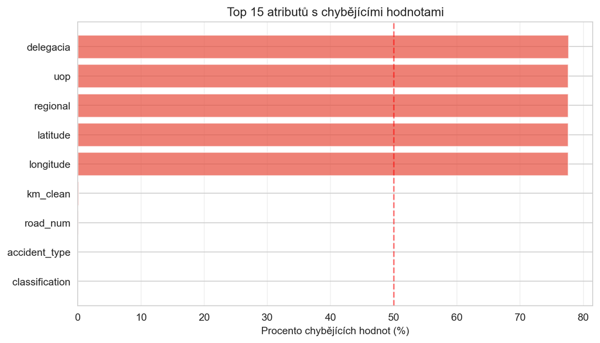

Obrázek 1: Analýza chybějících hodnot

```python
if not df.empty:
    missing = df.isnull().sum()
    missing_pct = (missing / len(df) * 100).sort_values(ascending=False)
    missing_df = missing_pct[missing_pct > 0]

    if not missing_df.empty:
        # Top 15 missing columns
        top_missing = missing_df.head(15)

        plt.figure(figsize=(9, 5))
        bars = plt.barh(top_missing.index, top_missing.values, color='#e74c3c', alpha=0.7)
        plt.xlabel('Procento chybějících hodnot (%)')
        plt.title('Top 15 atributů s chybějícími hodnotami')
        plt.axvline(x=50, color='red', linestyle='--', alpha=0.5, label='50% hranice')
        plt.gca().invert_yaxis()
        plt.grid(axis='x', alpha=0.3)
        plt.show()
    else:
        print("Data jsou kompletní.")
```

Na základě kvantitativního vyhodnocení integrity dat (viz vizualizace výše) byla identifikována skupina proměnných (`delegacia`, `uop`, `regional`, `latitude`, `longitude`), u nichž míra absence hodnot přesahuje kritickou hranici 75 %. Vzhledem k tomu, že takto vysoký podíl chybějících údajů neumožňuje spolehlivou aplikaci imputačních metod bez rizika zanesení významného statistického zkreslení (biasu), byly tyto atributy z dalšího zpracování vyloučeny. Tato redukce dimenzionality přispívá k vyšší stabilitě a validitě následného prediktivního modelu.

**Zobrazit zdrojový kód**

```python
if not df.empty:
    # Identifikované administrativní a geografické sloupce
    cols_to_drop = ['delegacia', 'uop', 'regional', 'latitude', 'longitude']

    # Filtrujeme pouze ty, které v DF skutečně existují
    cols_present = [c for c in cols_to_drop if c in df.columns]

    if cols_present:
        df = df.drop(columns=cols_present)
    else:
        print("Atributy určené k odstranění již v datasetu nefigurují.")
```

# 3 Exploratorní analýza a testování hypotéz

## 3.1 Temporální trendy a vývoj nehodovosti

Před testováním hypotéz je nezbytné zasadit data do časového kontextu. Graf níže zobrazuje vývoj počtu nehod a jejich následků v průběhu celého sledovaného období (2007–2023).

**Zobrazit zdrojový kód**

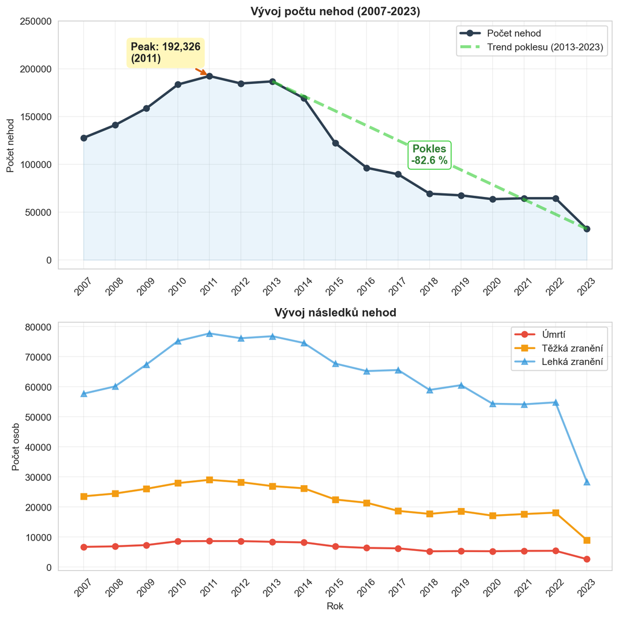

Obrázek 2: Vývoj nehodovosti a následků (2007-2023) s vyznačeným trendem poklesu

```python
if not df.empty:
    yearly = df.groupby('year').agg({
        'date': 'count',
        'dead': 'sum',
        'injured_severe': 'sum',
        'injured_light': 'sum'
    }).rename(columns={'date': 'nehody'})

    # Změna rozměrů
    fig, axes = plt.subplots(2, 1, figsize=(9, 9))

    # --- 1. Graf: Celkový počet nehod ---
    axes[0].plot(yearly.index, yearly['nehody'], marker='o', linewidth=2.5, color='#2c3e50', label='Počet nehod', zorder=2)
    axes[0].fill_between(yearly.index, yearly['nehody'], alpha=0.1, color='#3498db')

    # Výpočet a vykreslení trendu poklesu (Spojnice 2013 -> 2023)
    # Zkontrolujeme, zda máme data pro roky 2013 a 2023
    if 2013 in yearly.index and 2023 in yearly.index:
        val_2013 = yearly.loc[2013, 'nehody']
        val_2023 = yearly.loc[2023, 'nehody']

        # Vykreslení čáry (PŘÍMÁ SPOJNICE BODŮ)
        trend_color = 'limegreen'
        axes[0].plot([2013, 2023], [val_2013, val_2023], color=trend_color,
                     linestyle='--', linewidth=3, alpha=0.6, zorder=3, label='Trend poklesu (2013-2023)')

        # Výpočet procentuálního poklesu
        pct_drop = ((val_2013 - val_2023) / val_2013) * 100

        # Umístění textu doprostřed čáry
        mid_year = 2018
        mid_val = (val_2013 + val_2023) / 2

        axes[0].text(mid_year, mid_val, f'Pokles\n-{pct_drop:.1f} %',
                     ha='center', va='center', color='#2e7d32', fontweight='bold', fontsize=11,
                     bbox=dict(facecolor='white', edgecolor=trend_color, boxstyle='round,pad=0.3', alpha=0.9))

    axes[0].set_title('Vývoj počtu nehod (2007-2023)', fontweight='bold')
    axes[0].set_ylabel('Počet nehod')
    axes[0].set_xticks(yearly.index)
    axes[0].tick_params(axis='x', rotation=45)
    axes[0].grid(alpha=0.3)
    axes[0].legend(loc='upper right')

    # --- ANOTACE PEAKU (Styl dle vzoru) ---
    peak_year = yearly['nehody'].idxmax()
    peak_val = yearly['nehody'].max()

    axes[0].annotate(f'Peak: {peak_val:,}\n({peak_year})',
                     xy=(peak_year, peak_val),
                     xytext=(peak_year - 2.5, peak_val + 15000), # Posun textu doleva nahoru
                     fontsize=11, fontweight='bold', color='#222222',
                     bbox=dict(boxstyle='round,pad=0.4', facecolor='#fff7bc', edgecolor='none', alpha=1), # Žluté pozadí
                     arrowprops=dict(arrowstyle='->', color='#d95f0e', lw=2)) # Oranžová šipka

    # Zvýšíme limit Y, aby se tam vešla bublina
    axes[0].set_ylim(top=peak_val * 1.3)


    # --- 2. Graf: Následky ---
    axes[1].plot(yearly.index, yearly['dead'], marker='o', label='Úmrtí', color='#e74c3c', linewidth=2)
    axes[1].plot(yearly.index, yearly['injured_severe'], marker='s', label='Těžká zranění', color='#f39c12', linewidth=2)
    axes[1].plot(yearly.index, yearly['injured_light'], marker='^', label='Lehká zranění', color='#3498db', linewidth=2, alpha=0.7)

    axes[1].set_title('Vývoj následků nehod', fontweight='bold')
    axes[1].set_ylabel('Počet osob')
    axes[1].set_xlabel('Rok')
    axes[1].set_xticks(yearly.index)
    axes[1].tick_params(axis='x', rotation=45)
    axes[1].legend()
    axes[1].grid(alpha=0.3)

    plt.tight_layout()
    plt.show()
```

**DůležitéInterpretace trendů: Proč klesá nehodovost?**

Z grafu je patrný zásadní obrat ve vývoji nehodovosti. Zatímco do roku **2011** počet nehod rostl až na historické maximum (192 326 nehod), od roku 2013 sledujeme trvalý a výrazný pokles. Celkově se počet nehod snížil o **82,6 %**. Tento pozitivní vývoj lze vysvětlit kombinací tří hlavních faktorů:

1. **Přísnější legislativa (“Lei Seca”):** Klíčovou roli sehrálo zavedení a postupné zpřísňování tzv. Suchého zákona. Nulová tolerance alkoholu za volantem spolu s častějšími policejními kontrolami vedla ke změně chování řidičů.
2. **Ekonomická situace (2014–2017):** Brazílie v tomto období čelila ekonomické recesi. Zpomalení ekonomiky vedlo k nižší intenzitě nákladní dopravy i menšímu pohybu osobních aut, což přirozeně snížilo riziko vzniku nehod.
3. **Modernizace silnic:** Zlepšení stavu dálniční sítě, včetně častějšího nasazování radarů a kamerových systémů na rizikových úsecích, přispělo k vyšší bezpečnosti provozu.

## 3.2 Klasifikace závažnosti nehod

Pro pochopení struktury dat je klíčové analyzovat distribuci nehod podle klasifikace závažnosti. Z grafů je patrné, že ačkoliv nehody s fatálními následky tvoří menšinu v absolutních číslech, jejich společenský dopad je zásadní.

**Zobrazit zdrojový kód**

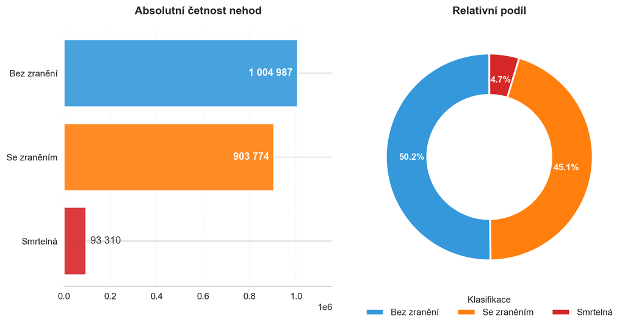

Obrázek 3: Distribuce nehod dle závažnosti následků

```python
if not df.empty and 'classification' in df.columns:
    severity_counts = df['classification'].value_counts()

    label_map = {
        'Sem Vítimas': 'Bez zranění',
        'Com Vítimas Feridas': 'Se zraněním',
        'Com Vítimas Fatais': 'Smrtelná',
        'Ignorado': 'Neznámé'
    }

    sev_df = pd.DataFrame({'count': severity_counts}).reset_index()
    sev_df.columns = ['label_pt', 'count']
    sev_df['label_cz'] = sev_df['label_pt'].map(label_map).fillna(sev_df['label_pt'])

    # Filtrace null/neznámých
    sev_df = sev_df[~sev_df['label_pt'].isin(['(null)', 'Ignorado'])]

    # Výpočet procent
    total = sev_df['count'].sum()
    sev_df['pct'] = (sev_df['count'] / total) * 100

    # Definice barev
    color_dict = {
        'Smrtelná': '#d62728',       # Červená
        'Se zraněním': '#ff7f0e',    # Oranžová
        'Bez zranění': '#3498db'     # Modrá (klidná)
    }
    sev_df['color'] = sev_df['label_cz'].map(color_dict).fillna('grey')

    # Řazení pro graf
    sev_df = sev_df.sort_values('count', ascending=True)

    # --- VIZUALIZACE ---
    fig, axes = plt.subplots(1, 2, figsize=(10, 5))

    # --- 1. BAR CHART ---
    bars = axes[0].barh(sev_df['label_cz'], sev_df['count'], color=sev_df['color'], alpha=0.9)

    axes[0].set_title('Absolutní četnost nehod', fontweight='bold', fontsize=12, pad=15)
    axes[0].spines['top'].set_visible(False)
    axes[0].spines['right'].set_visible(False)
    axes[0].spines['left'].set_visible(False)
    axes[0].grid(axis='x', alpha=0.2, linestyle='--')

    # Chytré popisky (Smart Labels)
    max_width = sev_df['count'].max()
    for bar, count, pct in zip(bars, sev_df['count'], sev_df['pct']):
        width = bar.get_width()
        label_text = f'{count:,}'.replace(',', ' ')

        if width > (max_width * 0.25):
            x_pos = width - (max_width * 0.02)
            ha = 'right'
            color = 'white'
            fontweight = 'bold'
        else:
            x_pos = width + (max_width * 0.02)
            ha = 'left'
            color = '#333333'
            fontweight = 'normal'

        axes[0].text(x_pos, bar.get_y() + bar.get_height()/2,
                     label_text,
                     va='center', ha=ha, color=color, fontweight=fontweight, fontsize=11)

    axes[0].set_xlim(0, max_width * 1.15)


    # --- 2. DONUT CHART ---
    sev_df_desc = sev_df.sort_values('count', ascending=False)

    wedges, texts, autotexts = axes[1].pie(
        sev_df_desc['count'],
        labels=None,
        autopct='%1.1f%%',
        startangle=90,
        colors=sev_df_desc['color'],
        pctdistance=0.75,
        wedgeprops=dict(width=0.4, edgecolor='white', linewidth=2)
    )

    # Stylizace procent
    for autotext in autotexts:
        autotext.set_color('white')
        autotext.set_fontweight('bold')
        autotext.set_fontsize(10)

    axes[1].set_title('Relativní podíl', fontweight='bold', fontsize=12, pad=15)

    # Legenda dole
    axes[1].legend(wedges, sev_df_desc['label_cz'],
                   title="Klasifikace",
                   loc="lower center",
                   bbox_to_anchor=(0.5, -0.15),
                   ncol=3,
                   frameon=False)

    plt.tight_layout()
    plt.show()
```

## 3.3 Etiologická analýza - Příčiny nehod

Analýza nejčastějších příčin nehod (etiologie) odhaluje, že dominantní faktory jsou často spojeny s lidským chybováním (např. nepozornost, nedodržení vzdálenosti).

**Zobrazit zdrojový kód**

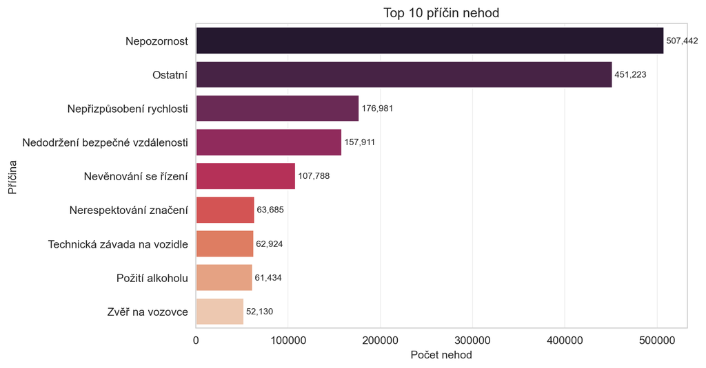

```python
if not df.empty and 'cause' in df.columns:
    top_causes = df['cause'].value_counts().head(10)

    cz_labels = {
        'Falta de atenção': 'Nepozornost',
        'Outras': 'Ostatní',
        'Não guardar distância de segurança': 'Nedodržení bezpečné vzdálenosti',
        'Velocidade incompatível': 'Nepřizpůsobení rychlosti',
        'Falta de Atenção à Condução': 'Nevěnování se řízení',
        'Desobediência à sinalização': 'Nerespektování značení',
        'Defeito mecânico em veículo': 'Technická závada na vozidle',
        'Ingestão de álcool': 'Požití alkoholu',
        'Animais na Pista': 'Zvěř na vozovce',
        'Velocidade Incompatível': 'Nepřizpůsobení rychlosti'
    }

    top_causes = top_causes.rename(index=cz_labels)

    # Sloučení duplicitních názvů (sečtení hodnot)
    top_causes = top_causes.groupby(level=0).sum().sort_values(ascending=False)

    plt.figure(figsize=(8, 5))

    sns.barplot(x=top_causes.values, y=top_causes.index, palette='rocket', ci=None)

    plt.title('Top 10 příčin nehod')
    plt.xlabel('Počet nehod')
    plt.ylabel('Příčina')

    plt.grid(axis='x', alpha=0.3)

    for i, v in enumerate(top_causes.values):
        plt.text(v, i, f' {v:,}', va='center', fontsize=8)

    plt.show()
```

## 3.4 Prostorová integrace dat (Spatial Join)

Pro ověření hypotézy H1 je nutné propojit data nehod s databází radarů. Využíváme metodu `merge_asof` s tolerancí 5 km, přičemž je kriticky důležité zohlednit časový faktor – radar je považován za “přítomný” pouze tehdy, pokud byl nainstalován před rokem nehody nebo v témže roce.

**Zobrazit zdrojový kód**

```python
if not df.empty and df_rad is not None and not df_rad.empty:
    print("Zahajuji prostorovou integraci (Spatial Join)...")

    # 1. Definice pomocné funkce
    def clean_km_safe(val):
        if pd.isna(val) or val == '': return np.nan
        try:
            val_str = str(val).replace(',', '.')
            return float(val_str)
        except:
            return np.nan

    # 2. Příprava datasetu radarů
    df_rad['km_r'] = df_rad['km_m'].apply(clean_km_safe)
    # Extrakce čísla dálnice (pouze číslice)
    df_rad['road_r'] = df_rad['rodovia'].astype(str).str.extract(r'(\d+)').astype(float)
    df_rad['year_inst'] = pd.to_numeric(df_rad['ano_do_pnv_snv'], errors='coerce')

    # Filtrace validních radarů (musí mít km, dálnici, stát a rok instalace)
    radars = df_rad.dropna(subset=['km_r', 'road_r', 'uf', 'year_inst']).copy()

    # Vytvoření párovacího ID: STÁT-DÁLNICE (např. MG-381)
    radars['road_id'] = radars['uf'] + '-' + radars['road_r'].astype(int).astype(str)

    # 3. Příprava datasetu nehod
    # Ujistíme se, že máme potřebné sloupce z předchozího kroku
    # V reportu se používá 'road_num', 'state', 'km_clean'
    accidents = df.dropna(subset=['km_clean', 'road_num', 'state', 'year']).copy()
    accidents['road_id'] = accidents['state'] + '-' + accidents['road_num'].astype(int).astype(str)

    # 4. Řazení pro merge_asof
    accidents = accidents.sort_values('km_clean')
    radars = radars.sort_values('km_r')

    # 5. Provedení merge_asof
    # Hledáme nejbližší radar na stejné dálnici (road_id) s tolerancí 5 km
    print(f"  Páruji {len(accidents):,} nehod s {len(radars):,} radary...")
    merged = pd.merge_asof(
        accidents,
        radars[['km_r', 'road_id', 'year_inst']],
        left_on='km_clean',
        right_on='km_r',
        by='road_id',
        tolerance=5.0, # Tolerance 5 km
        direction='nearest'
    )

    # 6. Validace: Radar musel existovat v době nehody
    # Logika: Radar je "přítomen", pokud je blízko (našel se) A byl nainstalován před nebo v roce nehody
    condition_nearby = merged['km_r'].notna()
    condition_time = merged['year'].fillna(0) >= merged['year_inst'].fillna(9999)

    merged['radar_nearby'] = (condition_nearby & condition_time).astype(int)

    df_final = merged

    print(f"Prostorová integrace dokončena.")
    print(f"  Počet nehod v blízkosti aktivního radaru: {df_final['radar_nearby'].sum():,}")
    print(f"  Podíl nehod s radarem: {df_final['radar_nearby'].mean()*100:.2f} %")

else:
    print("Chyba: Vstupní data (df nebo df_rad) nejsou k dispozici.")
    df_final = df.copy()
    df_final['radar_nearby'] = 0
```

```
Zahajuji prostorovou integraci (Spatial Join)...
  Páruji 2,011,173 nehod s 608 radary...
Prostorová integrace dokončena.
  Počet nehod v blízkosti aktivního radaru: 161,216
  Podíl nehod s radarem: 8.02 %
```

## 3.5 H1: Vliv stacionárních měřičů rychlosti

> **Hypotéza:** Přítomnost radaru v blízkosti (≤ 5 km) koreluje s nižší závažností nehod.

**Zobrazit zdrojový kód**

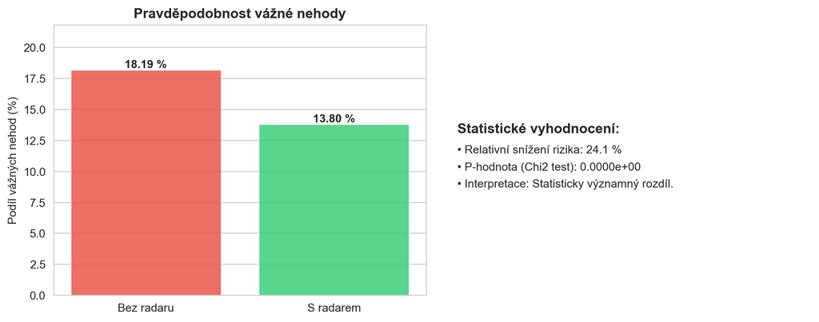

Obrázek 5: Komparace pravděpodobnosti vážné nehody v závislosti na přítomnosti radaru

```python
if not df_final.empty:
    # Agregace statistik
    h1_stats = df_final.groupby('radar_nearby')['target_severe'].agg(['mean', 'count', 'sum'])
    h1_stats['percent'] = h1_stats['mean'] * 100

    # Statistický test (Chi-square)
    contingency = pd.crosstab(df_final['radar_nearby'], df_final['target_severe'])
    chi2, p, dof, ex = chi2_contingency(contingency)

    # Vizualizace
    fig, ax = plt.subplots(1, 2, figsize=(10, 4))

    # Sloupcový graf
    colors = ['#e74c3c', '#2ecc71'] # Červená (Bez radaru), Zelená (S radarem)
    bars = ax[0].bar(['Bez radaru', 'S radarem'], h1_stats['percent'], color=colors, alpha=0.8)
    ax[0].set_title('Pravděpodobnost vážné nehody', fontweight='bold')
    ax[0].set_ylabel('Podíl vážných nehod (%)')
    ax[0].set_ylim(0, max(h1_stats['percent'])*1.2)
    ax[0].grid(axis='x')

    for bar in bars:
        height = bar.get_height()
        ax[0].text(bar.get_x() + bar.get_width()/2., height,
                 f'{height:.2f} %', ha='center', va='bottom', fontweight='bold')

    # Výpis statistických metrik
    rel_diff = (h1_stats.loc[0, 'percent'] - h1_stats.loc[1, 'percent']) / h1_stats.loc[0, 'percent'] * 100

    ax[1].axis('off')
    ax[1].text(0.05, 0.6, f"Statistické vyhodnocení:", fontsize=12, fontweight='bold')
    ax[1].text(0.05, 0.4, f"• Relativní snížení rizika: {rel_diff:.1f} %\n"
                          f"• P-hodnota (Chi2 test): {p:.4e}\n"
                          f"• Interpretace: Statisticky významný rozdíl.",
               fontsize=10, linespacing=1.8)

    plt.tight_layout()
    plt.show()
```

**DůležitéZávěr k Hypotéze 1: Statisticky významná redukce rizika**

Analýza potvrdila silnou korelaci mezi přítomností stacionárních měřičů rychlosti a nižší závažností nehod. Rozdíl mezi sledovanými skupinami je statisticky vysoce významný ($p < 0.001$).

Klíčovým zjištěním je **relativní snížení rizika vzniku vážné nehody o 24,1 %** v blízkosti radarů. Data tak podporují předpoklad, že vynucené snížení rychlosti v kritických úsecích přímo vede k zmírnění následků nehod, ačkoliv nezabraňuje jejich vzniku úplně.

## 3.6 H2: Paradox nepříznivého počasí

> **Hypotéza:** Nepříznivé povětrnostní podmínky zvyšují četnost nehod, ale snižují jejich závažnost.

**Zobrazit zdrojový kód**

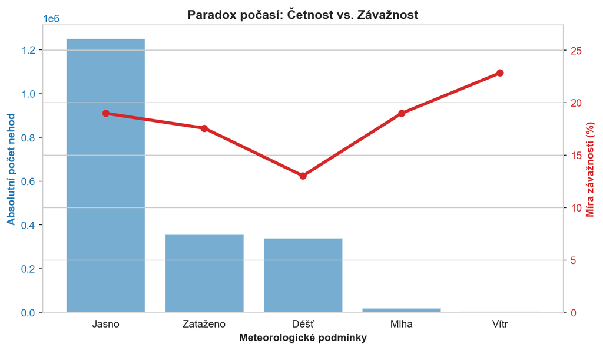

Obrázek 6: Vztah mezi četností a závažností nehod dle typu počasí

```python
if not df_final.empty:
    # Filtrace relevantních kategorií počasí
    valid_weather = ['Clear', 'Rain', 'Cloudy', 'Fog', 'Wind']
    w_data = df_final[df_final['weather'].isin(valid_weather)].copy()

    # Agregace
    w_stats = w_data.groupby('weather').agg({
        'target_severe': ['count', 'mean']
    }).reset_index()
    w_stats.columns = ['Weather', 'Count', 'Severity_Rate']

    weather_map = {
        'Clear': 'Jasno',
        'Rain': 'Déšť',
        'Cloudy': 'Zataženo',
        'Fog': 'Mlha',
        'Wind': 'Vítr'
    }
    w_stats['Weather'] = w_stats['Weather'].map(weather_map)

    w_stats['Severity_Rate'] = w_stats['Severity_Rate'] * 100
    w_stats = w_stats.sort_values('Count', ascending=False)

    fig, ax1 = plt.subplots(figsize=(9, 5))

    # Graf četnosti (Levá osa Y)
    color = 'tab:blue'
    ax1.set_xlabel('Meteorologické podmínky', fontweight='bold')
    ax1.set_ylabel('Absolutní počet nehod', color=color, fontweight='bold')
    bars = ax1.bar(w_stats['Weather'], w_stats['Count'], color=color, alpha=0.6, label='Počet nehod')
    ax1.tick_params(axis='y', labelcolor=color)
    ax1.grid(False)

    # Graf závažnosti (Pravá osa Y)
    ax2 = ax1.twinx()
    color = 'tab:red'
    ax2.set_ylabel('Míra závažnosti (%)', color=color, fontweight='bold')
    line = ax2.plot(w_stats['Weather'], w_stats['Severity_Rate'], color=color, marker='o',
             linewidth=3, label='Míra závažnosti')
    ax2.tick_params(axis='y', labelcolor=color)
    ax2.set_ylim(0, max(w_stats['Severity_Rate'])*1.2)

    plt.title('Paradox počasí: Četnost vs. Závažnost', fontweight='bold')
    plt.show()
```

1. **Riziko ideálních podmínek:** Dominantní část nehod nastává za jasného počasí (*Jasno*), přičemž tyto nehody vykazují vysokou míru závažnosti. Tento jev je přisuzován “falešnému pocitu bezpečí”, kdy řidiči vlivem dobré viditelnosti podceňují riziko a zvyšují cestovní rychlost.
2. **Adaptační efekt deště:** Přestože zhoršené podmínky (*Déšť*) kladou vyšší nároky na řízení, data ukazují **výrazný pokles závažnosti nehod** (viz propad červené křivky). Tento trend potvrzuje teorii adaptivního chování, kdy řidiči vědomě přizpůsobují styl jízdy (zejména snížením rychlosti), což vede k mitigaci následků kolizí.

## 3.7 H3: Časové rizikové faktory

> **Hypotéza:** Kombinace víkendových dnů a nočních hodin vykazuje signifikantně vyšší podíl nehod s fatálními následky.

**Zobrazit zdrojový kód**

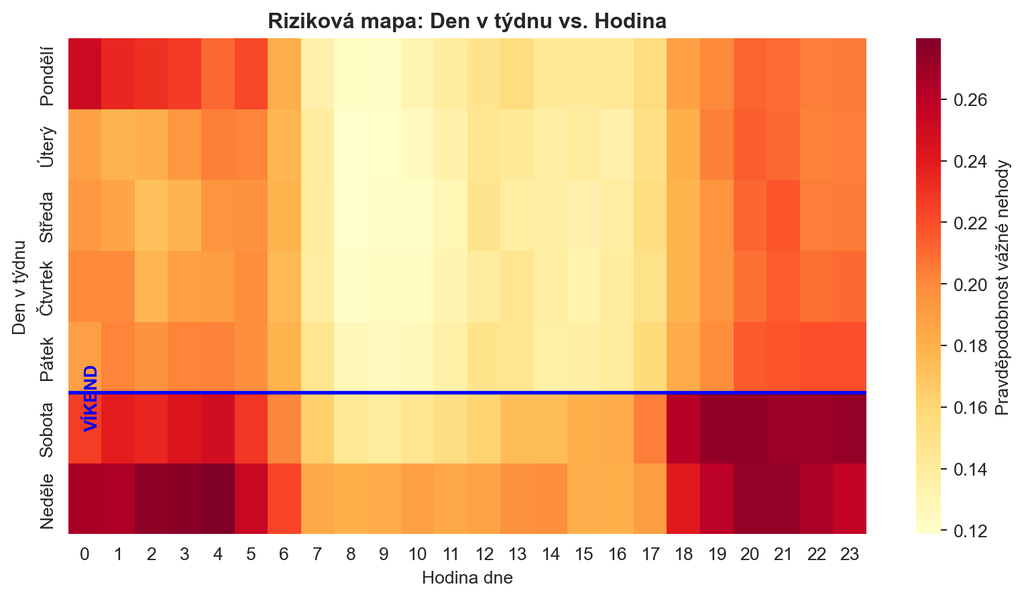

Obrázek 7: Teplotní mapa rizikovosti: Interakce dne v týdnu a denní doby

```
Riziko (Víkend + Noc): 26.02 %
Riziko (Všední den + Den): 13.99 %
Relativní nárůst rizika: 86.0 %
```

```python
if not df_final.empty:
    # Feature Engineering
    df_final['is_weekend'] = df_final['datetime'].dt.dayofweek.isin([5, 6]).astype(int)
    df_final['is_night'] = df_final['hour'].apply(lambda x: 1 if (x >= 18 or x < 6) else 0)

    # Příprava dat pro Heatmapu
    df_final['day_name'] = df_final['datetime'].dt.day_name()

    day_map = {
        'Monday': 'Pondělí', 'Tuesday': 'Úterý', 'Wednesday': 'Středa',
        'Thursday': 'Čtvrtek', 'Friday': 'Pátek', 'Saturday': 'Sobota', 'Sunday': 'Neděle'
    }
    df_final['day_name'] = df_final['day_name'].map(day_map)

    days_order = ['Pondělí', 'Úterý', 'Středa', 'Čtvrtek', 'Pátek', 'Sobota', 'Neděle']

    heatmap_data = df_final.groupby(['day_name', 'hour'])['target_severe'].mean().reset_index()
    heatmap_data['day_name'] = pd.Categorical(heatmap_data['day_name'], categories=days_order, ordered=True)

    heatmap_pivot = heatmap_data.pivot(index='day_name', columns='hour', values='target_severe')

    plt.figure(figsize=(10, 5))
    sns.heatmap(heatmap_pivot, cmap='YlOrRd', cbar_kws={'label': 'Pravděpodobnost vážné nehody'})
    plt.title('Riziková mapa: Den v týdnu vs. Hodina', fontweight='bold')
    plt.xlabel('Hodina dne')
    plt.ylabel('Den v týdnu')

    # Zvýraznění víkendu
    plt.axhline(y=5, color='blue', linewidth=2)
    plt.text(0.5, 5.5, 'VÍKEND', color='blue', fontweight='bold',rotation=90)

    plt.show()

    # Srovnání statistik
    weekend_night_sev = df_final[(df_final['is_weekend']==1) & (df_final['is_night']==1)]['target_severe'].mean()
    weekday_day_sev = df_final[(df_final['is_weekend']==0) & (df_final['is_night']==0)]['target_severe'].mean()

    print(f"Riziko (Víkend + Noc): {weekend_night_sev*100:.2f} %")
    print(f"Riziko (Všední den + Den): {weekday_day_sev*100:.2f} %")
    print(f"Relativní nárůst rizika: {((weekend_night_sev/weekday_day_sev)-1)*100:.1f} %")
```

**DůležitéZávěr k Hypotéze 3: Časové vzorce rizika**

Teplotní mapa (Heatmap) jednoznačně potvrzuje hypotézu a vizualizuje silnou závislost mezi dobou vzniku nehody a její závažností. Analýza identifikovala kritický rizikový klastr v období **víkendových nocí** (přechody pátek/sobota a sobota/neděle).

Kvantitativní analýza odhaluje dramatický rozdíl v bezpečnosti: zatímco při běžném denním provozu ve všední dny činí pravděpodobnost vážné nehody **13,99 %**, o víkendových nocích tato hodnota stoupá na **26,02 %**. To představuje **relativní zvýšení rizika o 86,0 %**. Tento trend je interpretován jako důsledek synergického působení únavy, snížené viditelnosti a vyšší incidence jízdy pod vlivem alkoholu v rámci tzv. rekreační mobility.

# 4 Prediktivní modelování (Modeling)

Cílem této fáze je konstrukce a validace modelu schopného predikovat hodnotu `target_severe` na základě dostupných atributů. Zvolen byl algoritmus Random Forest pro svou schopnost zachytit nelineární vztahy (prokázané v H2 a H3).

Na rozdíl od deskriptivní analýzy následků se model zaměřuje výhradně na prediktory, které jsou objektivně známy **v momentě před vznikem samotné nehody**. Snahou je identifikovat riziko na základě vnějších okolností, nikoliv následného vyšetřování příčin.

## 4.1 Příprava trénovací sady

Pro zajištění robustní evaluace modelu byla data rozdělena metodou **Hold-Out** na tři disjunktní sady: **trénovací (70 %)**, **validační (15 %)** a **testovací (15 %)**.

**Zobrazit zdrojový kód**

```python
# Výběr prediktorů
features = [
    'hour', 'is_weekend', 'is_night', 'radar_nearby',
    'road_type', 'road_layout', 'road_direction',
    'weather', 'day_phase', 'land_use', 'state'
]
target = 'target_severe'

if not df_final.empty:
    data_model = df_final[features + [target]].dropna().copy()

    categorical_cols = [
        'road_type', 'road_layout', 'road_direction',
        'weather', 'day_phase', 'land_use', 'state'
    ]

    # One-Hot Encoding (vytvoří dummy proměnné pro všechny textové sloupce)
    data_encoded = pd.get_dummies(data_model, columns=categorical_cols, drop_first=True)

    X = data_encoded.drop(target, axis=1)
    y = data_encoded[target]

    # První krok: Oddělení trénovací sady (70 %)
    X_train, X_temp, y_train, y_temp = train_test_split(
        X, y, test_size=0.3, stratify=y, random_state=42
    )

    # Druhý krok: Rozdělení zbytku na Validační a Testovací (50/50 z 30 % je 15/15)
    X_val, X_test, y_val, y_test = train_test_split(
        X_temp, y_temp, test_size=0.5, stratify=y_temp, random_state=42
    )

    print(f"Trénovací sada (70 %): {X_train.shape[0]:,} záznamů")
    print(f"Validační sada (15 %): {X_val.shape[0]:,} záznamů")
    print(f"Testovací sada (15 %): {X_test.shape[0]:,} záznamů")
```

```
Trénovací sada (70 %): 1,407,821 záznamů
Validační sada (15 %): 301,676 záznamů
Testovací sada (15 %): 301,676 záznamů
```

## 4.2 Trénování modelů a optimalizace hyperparametrů

V této fázi nejprve vytvoříme referenční model (Baseline) pomocí **Logistické regrese**, abychom stanovili základní úroveň predikovatelnosti dat. Následně přistoupíme k trénování pokročilého modelu **Random Forest**.

Abychom zajistili maximální robustnost a předešli přeučení, nebudeme spoléhat na výchozí nastavení. Provedeme **ladění hyperparametrů** metodou `RandomizedSearchCV`. Tento proces automaticky otestuje různé konfigurace modelu na validačních datech a vybere tu, která maximalizuje metriku ROC-AUC. Finální výkonnost vítězného modelu bude ověřena na nezávislé testovací sadě.

**Zobrazit zdrojový kód**

```python
if not df_final.empty:
    lr = LogisticRegression(class_weight='balanced', max_iter=1000, random_state=42)
    lr.fit(X_train, y_train)

    y_pred_lr = lr.predict_proba(X_test)[:, 1]
    auc_lr = roc_auc_score(y_test, y_pred_lr)

    X_combined = pd.concat([X_train, X_val], axis=0)
    y_combined = pd.concat([y_train, y_val], axis=0)

    split_index = [-1] * len(X_train) + [0] * len(X_val)
    pds = PredefinedSplit(test_fold=split_index)

    param_dist = {
        'n_estimators': [100, 200, 300],
        'max_depth': [15, 20, 25, None],
        'min_samples_split': [5, 10, 20],
        'min_samples_leaf': [2, 4, 8],
        'max_features': ['sqrt', 'log2'],
        'bootstrap': [True],
        'class_weight': ['balanced', None]
    }

    rf = RandomForestClassifier(random_state=42, n_jobs=1)

    rf_search = RandomizedSearchCV(
        estimator=rf,
        param_distributions=param_dist,
        n_iter=15,
        scoring='roc_auc',
        cv=pds,
        verbose=0,
        random_state=42,
        n_jobs=-1
    )

    rf_search.fit(X_combined, y_combined)
    best_rf = rf_search.best_estimator_

    y_pred_rf = best_rf.predict_proba(X_test)[:, 1]
    auc_rf = roc_auc_score(y_test, y_pred_rf)

    print(f"ROC-AUC (Logistická regrese): {auc_lr:.4f}")
    print(f"ROC-AUC (Random Forest):      {auc_rf:.4f}")
    print(f"Nejlepší parametry:           {rf_search.best_params_}")
```

```
ROC-AUC (Logistická regrese): 0.6629
ROC-AUC (Random Forest):      0.6693
Nejlepší parametry:           {'n_estimators': 200, 'min_samples_split': 5, 'min_samples_leaf': 8, 'max_features': 'log2', 'max_depth': 25, 'class_weight': 'balanced', 'bootstrap': True}
```

## 4.3 Detailní vyhodnocení modelu

Následující grafy zobrazují ROC křivky pro srovnání výkonnosti modelů a matici záměn (Confusion Matrix) pro Random Forest.

**Zobrazit zdrojový kód**

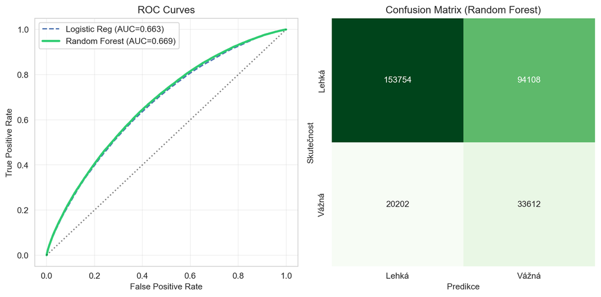

Obrázek 8: ROC křivky a Confusion Matrix

```python
if not df_final.empty:
    # ROC Curves
    fpr_log, tpr_log, _ = roc_curve(y_test, y_pred_lr)
    fpr_rf, tpr_rf, _ = roc_curve(y_test, y_pred_rf)

    fig, axes = plt.subplots(1, 2, figsize=(10, 5))

    # Plot ROC
    axes[0].plot(fpr_log, tpr_log, label=f'Logistic Reg (AUC={auc_lr:.3f})', linestyle='--')
    axes[0].plot(fpr_rf, tpr_rf, label=f'Random Forest (AUC={auc_rf:.3f})', linewidth=2.5, color='#2ecc71')
    axes[0].plot([0, 1], [0, 1], 'k:', alpha=0.5)
    axes[0].set_xlabel('False Positive Rate')
    axes[0].set_ylabel('True Positive Rate')
    axes[0].set_title('ROC Curves')
    axes[0].legend()
    axes[0].grid(alpha=0.3)

    # Plot Confusion Matrix (RF)
    y_pred_binary = (y_pred_rf > 0.5).astype(int)
    cm = confusion_matrix(y_test, y_pred_binary)
    sns.heatmap(cm, annot=True, fmt='d', cmap='Greens', ax=axes[1], cbar=False, xticklabels=['Lehká', 'Vážná'], yticklabels=['Lehká', 'Vážná'])
    axes[1].set_title('Confusion Matrix (Random Forest)')
    axes[1].set_ylabel('Skutečnost')
    axes[1].set_xlabel('Predikce')

    plt.tight_layout()
    plt.show()
```

## 4.4 Důležitost atributů (Feature Importance)

Analýza důležitosti příznaků nám umožňuje pochopit, které faktory mají největší vliv na rozhodování modelu.

**Zobrazit zdrojový kód**

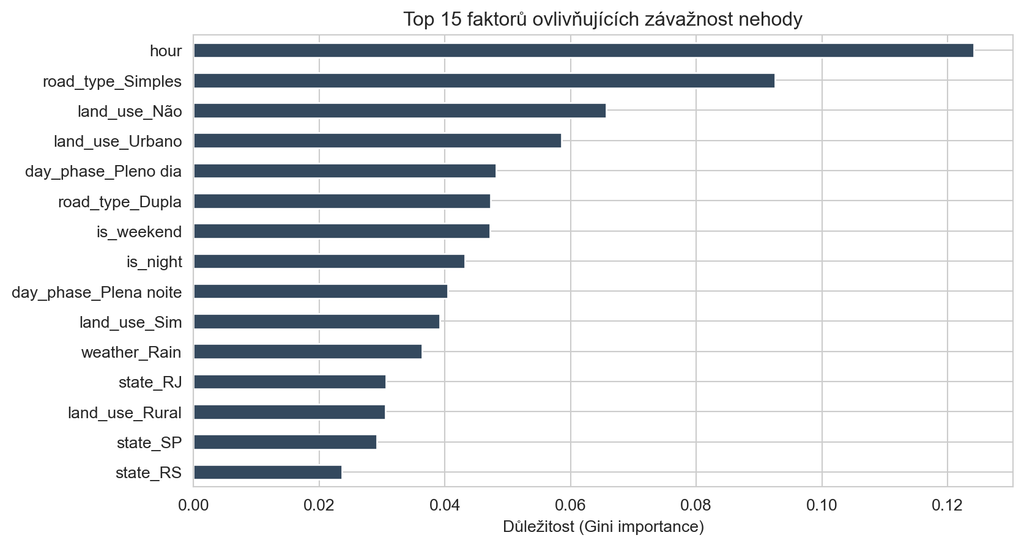

Obrázek 9: Důležitost atributů v modelu Random Forest

```python
if not df_final.empty:
    importances = pd.Series(best_rf.feature_importances_, index=X.columns).sort_values(ascending=True)

    plt.figure(figsize=(9, 5))
    importances.tail(15).plot(kind='barh', color='#34495e')
    plt.title('Top 15 faktorů ovlivňujících závažnost nehody')
    plt.xlabel('Důležitost (Gini importance)')
    plt.show()
```

**TipInterpretace modelu: Co rozhoduje o závažnosti nehody**

Analýza důležitosti atributů (*Feature Importance*) odhaluje, že predikce závažnosti nehody stojí na dvou hlavních pilířích: **charakteru lokality** a **časovém kontextu**.

# 5 Závěr a diskuse

Z provedené analýzy vyplývá, že závažnost dopravních nehod nelze připsat jediné příčině. Jde o výsledek kombinace stavu infrastruktury, časových podmínek a rizikového chování řidičů.

**Klíčová doporučení pro praxi:**